# Risk Factor Analysis

## Outcome Variable

**Outcome Variable:** ever_stunted

## Predictor Variables

**Intervention Variable:** pers_wast

**Adjustment Set:**

unadjusted

## Stratifying Variables

The analysis was stratified on these variable(s):

- agecat
- studyid
- country

## Data Summary

| agecat | studyid | country | pers_wast | ever_stunted | n_cell | n |
| --- | --- | --- | --- | --- | --- | --- |
| 0-24 months (no birth st.) | ki0047075b-MAL-ED | BANGLADESH | 0 | 0 | 98 | 217 |
| 0-24 months (no birth st.) | ki0047075b-MAL-ED | BANGLADESH | 0 | 1 | 112 | 217 |
| 0-24 months (no birth st.) | ki0047075b-MAL-ED | BANGLADESH | 1 | 0 | 6 | 217 |
| 0-24 months (no birth st.) | ki0047075b-MAL-ED | BANGLADESH | 1 | 1 | 1 | 217 |
| 0-24 months (no birth st.) | ki0047075b-MAL-ED | BRAZIL | 0 | 0 | 178 | 208 |
| 0-24 months (no birth st.) | ki0047075b-MAL-ED | BRAZIL | 0 | 1 | 29 | 208 |
| 0-24 months (no birth st.) | ki0047075b-MAL-ED | BRAZIL | 1 | 0 | 1 | 208 |
| 0-24 months (no birth st.) | ki0047075b-MAL-ED | BRAZIL | 1 | 1 | 0 | 208 |
| 0-24 months (no birth st.) | ki0047075b-MAL-ED | INDIA | 0 | 0 | 89 | 209 |
| 0-24 months (no birth st.) | ki0047075b-MAL-ED | INDIA | 0 | 1 | 101 | 209 |
| 0-24 months (no birth st.) | ki0047075b-MAL-ED | INDIA | 1 | 0 | 12 | 209 |
| 0-24 months (no birth st.) | ki0047075b-MAL-ED | INDIA | 1 | 1 | 7 | 209 |
| 0-24 months (no birth st.) | ki0047075b-MAL-ED | NEPAL | 0 | 0 | 153 | 212 |
| 0-24 months (no birth st.) | ki0047075b-MAL-ED | NEPAL | 0 | 1 | 54 | 212 |
| 0-24 months (no birth st.) | ki0047075b-MAL-ED | NEPAL | 1 | 0 | 4 | 212 |
| 0-24 months (no birth st.) | ki0047075b-MAL-ED | NEPAL | 1 | 1 | 1 | 212 |
| 0-24 months (no birth st.) | ki0047075b-MAL-ED | PERU | 0 | 0 | 115 | 266 |
| 0-24 months (no birth st.) | ki0047075b-MAL-ED | PERU | 0 | 1 | 151 | 266 |
| 0-24 months (no birth st.) | ki0047075b-MAL-ED | PERU | 1 | 0 | 0 | 266 |
| 0-24 months (no birth st.) | ki0047075b-MAL-ED | PERU | 1 | 1 | 0 | 266 |
| 0-24 months (no birth st.) | ki0047075b-MAL-ED | SOUTH AFRICA | 0 | 0 | 136 | 280 |
| 0-24 months (no birth st.) | ki0047075b-MAL-ED | SOUTH AFRICA | 0 | 1 | 137 | 280 |
| 0-24 months (no birth st.) | ki0047075b-MAL-ED | SOUTH AFRICA | 1 | 0 | 7 | 280 |
| 0-24 months (no birth st.) | ki0047075b-MAL-ED | SOUTH AFRICA | 1 | 1 | 0 | 280 |
| 0-24 months (no birth st.) | ki0047075b-MAL-ED | TANZANIA, UNITED REPUBLIC OF | 0 | 0 | 41 | 219 |
| 0-24 months (no birth st.) | ki0047075b-MAL-ED | TANZANIA, UNITED REPUBLIC OF | 0 | 1 | 178 | 219 |
| 0-24 months (no birth st.) | ki0047075b-MAL-ED | TANZANIA, UNITED REPUBLIC OF | 1 | 0 | 0 | 219 |
| 0-24 months (no birth st.) | ki0047075b-MAL-ED | TANZANIA, UNITED REPUBLIC OF | 1 | 1 | 0 | 219 |
| 0-24 months (no birth st.) | ki1000108-CMC-V-BCS-2002 | INDIA | 0 | 0 | 24 | 293 |
| 0-24 months (no birth st.) | ki1000108-CMC-V-BCS-2002 | INDIA | 0 | 1 | 228 | 293 |

[output cut: 198 more lines]

The following strata were considered:

- agecat: 0-24 months (no birth st.), studyid: ki0047075b-MAL-ED, country: BANGLADESH
- agecat: 0-24 months (no birth st.), studyid: ki0047075b-MAL-ED, country: BRAZIL
- agecat: 0-24 months (no birth st.), studyid: ki0047075b-MAL-ED, country: INDIA
- agecat: 0-24 months (no birth st.), studyid: ki0047075b-MAL-ED, country: NEPAL
- agecat: 0-24 months (no birth st.), studyid: ki0047075b-MAL-ED, country: PERU
- agecat: 0-24 months (no birth st.), studyid: ki0047075b-MAL-ED, country: SOUTH AFRICA
- agecat: 0-24 months (no birth st.), studyid: ki0047075b-MAL-ED, country: TANZANIA, UNITED REPUBLIC OF
- agecat: 0-24 months (no birth st.), studyid: ki1000108-CMC-V-BCS-2002, country: INDIA
- agecat: 0-24 months (no birth st.), studyid: ki1000108-IRC, country: INDIA
- agecat: 0-24 months (no birth st.), studyid: ki1000109-EE, country: PAKISTAN
- agecat: 0-24 months (no birth st.), studyid: ki1000109-ResPak, country: PAKISTAN
- agecat: 0-24 months (no birth st.), studyid: ki1017093b-PROVIDE, country: BANGLADESH
- agecat: 0-24 months (no birth st.), studyid: ki1066203-TanzaniaChild2, country: TANZANIA, UNITED REPUBLIC OF
- agecat: 0-24 months (no birth st.), studyid: ki1101329-Keneba, country: GAMBIA
- agecat: 0-24 months (no birth st.), studyid: ki1112895-Guatemala BSC, country: GUATEMALA
- agecat: 0-24 months (no birth st.), studyid: ki1113344-GMS-Nepal, country: NEPAL
- agecat: 0-24 months (no birth st.), studyid: ki1114097-CMIN, country: BANGLADESH
- agecat: 0-24 months (no birth st.), studyid: ki1114097-CMIN, country: PERU
- agecat: 0-24 months (no birth st.), studyid: ki1114097-CONTENT, country: PERU
- agecat: 0-6 months (no birth st.), studyid: ki0047075b-MAL-ED, country: BANGLADESH
- agecat: 0-6 months (no birth st.), studyid: ki0047075b-MAL-ED, country: BRAZIL
- agecat: 0-6 months (no birth st.), studyid: ki0047075b-MAL-ED, country: INDIA
- agecat: 0-6 months (no birth st.), studyid: ki0047075b-MAL-ED, country: NEPAL
- agecat: 0-6 months (no birth st.), studyid: ki0047075b-MAL-ED, country: PERU
- agecat: 0-6 months (no birth st.), studyid: ki0047075b-MAL-ED, country: SOUTH AFRICA
- agecat: 0-6 months (no birth st.), studyid: ki0047075b-MAL-ED, country: TANZANIA, UNITED REPUBLIC OF
- agecat: 0-6 months (no birth st.), studyid: ki1000108-CMC-V-BCS-2002, country: INDIA
- agecat: 0-6 months (no birth st.), studyid: ki1000108-IRC, country: INDIA
- agecat: 0-6 months (no birth st.), studyid: ki1000109-EE, country: PAKISTAN
- agecat: 0-6 months (no birth st.), studyid: ki1000109-ResPak, country: PAKISTAN
- agecat: 0-6 months (no birth st.), studyid: ki1017093b-PROVIDE, country: BANGLADESH
- agecat: 0-6 months (no birth st.), studyid: ki1066203-TanzaniaChild2, country: TANZANIA, UNITED REPUBLIC OF
- agecat: 0-6 months (no birth st.), studyid: ki1101329-Keneba, country: GAMBIA
- agecat: 0-6 months (no birth st.), studyid: ki1112895-Guatemala BSC, country: GUATEMALA
- agecat: 0-6 months (no birth st.), studyid: ki1113344-GMS-Nepal, country: NEPAL
- agecat: 0-6 months (no birth st.), studyid: ki1114097-CMIN, country: BANGLADESH
- agecat: 0-6 months (no birth st.), studyid: ki1114097-CMIN, country: PERU
- agecat: 0-6 months (no birth st.), studyid: ki1114097-CONTENT, country: PERU
- agecat: 6-24 months, studyid: ki0047075b-MAL-ED, country: BANGLADESH
- agecat: 6-24 months, studyid: ki0047075b-MAL-ED, country: BRAZIL
- agecat: 6-24 months, studyid: ki0047075b-MAL-ED, country: INDIA
- agecat: 6-24 months, studyid: ki0047075b-MAL-ED, country: NEPAL
- agecat: 6-24 months, studyid: ki0047075b-MAL-ED, country: PERU
- agecat: 6-24 months, studyid: ki0047075b-MAL-ED, country: SOUTH AFRICA
- agecat: 6-24 months, studyid: ki0047075b-MAL-ED, country: TANZANIA, UNITED REPUBLIC OF
- agecat: 6-24 months, studyid: ki1000108-CMC-V-BCS-2002, country: INDIA
- agecat: 6-24 months, studyid: ki1000108-IRC, country: INDIA
- agecat: 6-24 months, studyid: ki1000109-EE, country: PAKISTAN
- agecat: 6-24 months, studyid: ki1000109-ResPak, country: PAKISTAN
- agecat: 6-24 months, studyid: ki1017093b-PROVIDE, country: BANGLADESH
- agecat: 6-24 months, studyid: ki1066203-TanzaniaChild2, country: TANZANIA, UNITED REPUBLIC OF
- agecat: 6-24 months, studyid: ki1101329-Keneba, country: GAMBIA
- agecat: 6-24 months, studyid: ki1112895-Guatemala BSC, country: GUATEMALA
- agecat: 6-24 months, studyid: ki1113344-GMS-Nepal, country: NEPAL
- agecat: 6-24 months, studyid: ki1114097-CMIN, country: BANGLADESH
- agecat: 6-24 months, studyid: ki1114097-CMIN, country: PERU
- agecat: 6-24 months, studyid: ki1114097-CONTENT, country: PERU

### Dropped Strata

Some strata were dropped due to rare outcomes:

- agecat: 0-24 months (no birth st.), studyid: ki0047075b-MAL-ED, country: BANGLADESH
- agecat: 0-24 months (no birth st.), studyid: ki0047075b-MAL-ED, country: BRAZIL
- agecat: 0-24 months (no birth st.), studyid: ki0047075b-MAL-ED, country: NEPAL
- agecat: 0-24 months (no birth st.), studyid: ki0047075b-MAL-ED, country: PERU
- agecat: 0-24 months (no birth st.), studyid: ki0047075b-MAL-ED, country: SOUTH AFRICA
- agecat: 0-24 months (no birth st.), studyid: ki0047075b-MAL-ED, country: TANZANIA, UNITED REPUBLIC OF
- agecat: 0-24 months (no birth st.), studyid: ki1000108-CMC-V-BCS-2002, country: INDIA
- agecat: 0-24 months (no birth st.), studyid: ki1000109-EE, country: PAKISTAN
- agecat: 0-24 months (no birth st.), studyid: ki1112895-Guatemala BSC, country: GUATEMALA
- agecat: 0-24 months (no birth st.), studyid: ki1114097-CMIN, country: BANGLADESH
- agecat: 0-24 months (no birth st.), studyid: ki1114097-CONTENT, country: PERU
- agecat: 0-6 months (no birth st.), studyid: ki0047075b-MAL-ED, country: BANGLADESH
- agecat: 0-6 months (no birth st.), studyid: ki0047075b-MAL-ED, country: BRAZIL
- agecat: 0-6 months (no birth st.), studyid: ki0047075b-MAL-ED, country: NEPAL
- agecat: 0-6 months (no birth st.), studyid: ki0047075b-MAL-ED, country: PERU
- agecat: 0-6 months (no birth st.), studyid: ki0047075b-MAL-ED, country: SOUTH AFRICA
- agecat: 0-6 months (no birth st.), studyid: ki0047075b-MAL-ED, country: TANZANIA, UNITED REPUBLIC OF
- agecat: 0-6 months (no birth st.), studyid: ki1112895-Guatemala BSC, country: GUATEMALA
- agecat: 0-6 months (no birth st.), studyid: ki1114097-CMIN, country: BANGLADESH
- agecat: 0-6 months (no birth st.), studyid: ki1114097-CONTENT, country: PERU
- agecat: 6-24 months, studyid: ki0047075b-MAL-ED, country: BANGLADESH
- agecat: 6-24 months, studyid: ki0047075b-MAL-ED, country: BRAZIL
- agecat: 6-24 months, studyid: ki0047075b-MAL-ED, country: INDIA
- agecat: 6-24 months, studyid: ki0047075b-MAL-ED, country: NEPAL
- agecat: 6-24 months, studyid: ki0047075b-MAL-ED, country: PERU
- agecat: 6-24 months, studyid: ki0047075b-MAL-ED, country: SOUTH AFRICA
- agecat: 6-24 months, studyid: ki0047075b-MAL-ED, country: TANZANIA, UNITED REPUBLIC OF
- agecat: 6-24 months, studyid: ki1000108-CMC-V-BCS-2002, country: INDIA
- agecat: 6-24 months, studyid: ki1000109-EE, country: PAKISTAN
- agecat: 6-24 months, studyid: ki1000109-ResPak, country: PAKISTAN
- agecat: 6-24 months, studyid: ki1017093b-PROVIDE, country: BANGLADESH
- agecat: 6-24 months, studyid: ki1112895-Guatemala BSC, country: GUATEMALA
- agecat: 6-24 months, studyid: ki1114097-CMIN, country: BANGLADESH
- agecat: 6-24 months, studyid: ki1114097-CMIN, country: PERU
- agecat: 6-24 months, studyid: ki1114097-CONTENT, country: PERU

## Methods Detail

We’re interested in the causal parameters $E[Y_a]$ for all values of $a \in \mathcal{A}$. These parameters represent the mean outcome if, possibly contrary to fact, we intervened to set all units to have $A=a$. Under the randomization and positivity assumptions, these are identified by the statistical parameters $\psi_a=E_W[E_{Y|A,W}(Y|A=a,W)]$. In addition, we’re interested in the mean of $Y$, $E[Y]$ under no intervention (the observed mean). We will estimate these parameters by using SuperLearner to fit the relevant likelihood factors – $E_{Y|A,W}(Y|A=a,W)$ and $p(A=a|W)$, and then updating our likelihood fit using a joint TMLE.

For unadjusted analyses ($W=\{\}$), initial likelihoods were estimated using Lrnr_glm to estimate the simple $E(Y|A)$ and Lrnr_mean to estimate $p(A)$. For adjusted analyses, a small library containing Lrnr_glmnet, Lrnr_xgboost, and Lrnr_mean was used.

Having estimated these parameters, we will then use the delta method to estimate relative risks and attributable risks relative to a prespecified baseline level of $A$.

# Results Detail

## Results Plots

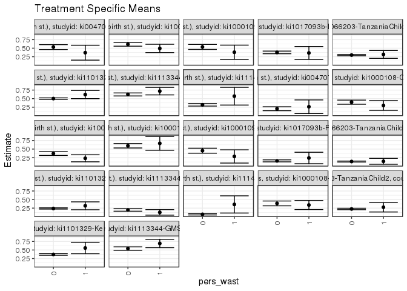

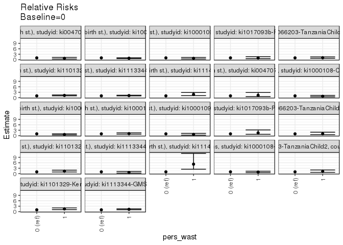

[figure not shown]

[figure not shown]

## Results Table

### Parameter: TSM

| agecat | studyid | country | intervention_level | baseline_level | estimate | ci_lower | ci_upper |
| --- | --- | --- | --- | --- | --- | --- | --- |
| 0-24 months (no birth st.) | ki0047075b-MAL-ED | INDIA | 0 | NA | 0.5315789 | 0.4604552 | 0.6027027 |
| 0-24 months (no birth st.) | ki0047075b-MAL-ED | INDIA | 1 | NA | 0.3684211 | 0.1510014 | 0.5858407 |
| 0-24 months (no birth st.) | ki1000108-IRC | INDIA | 0 | NA | 0.6135593 | 0.5579163 | 0.6692024 |
| 0-24 months (no birth st.) | ki1000108-IRC | INDIA | 1 | NA | 0.4923077 | 0.3706011 | 0.6140143 |
| 0-24 months (no birth st.) | ki1000109-ResPak | PAKISTAN | 0 | NA | 0.5359116 | 0.4630777 | 0.6087455 |
| 0-24 months (no birth st.) | ki1000109-ResPak | PAKISTAN | 1 | NA | 0.3809524 | 0.1727367 | 0.5891681 |
| 0-24 months (no birth st.) | ki1017093b-PROVIDE | BANGLADESH | 0 | NA | 0.3760263 | 0.3375251 | 0.4145275 |
| 0-24 months (no birth st.) | ki1017093b-PROVIDE | BANGLADESH | 1 | NA | 0.3600000 | 0.1716949 | 0.5483051 |
| 0-24 months (no birth st.) | ki1066203-TanzaniaChild2 | TANZANIA, UNITED REPUBLIC OF | 0 | NA | 0.2983425 | 0.2790968 | 0.3175883 |
| 0-24 months (no birth st.) | ki1066203-TanzaniaChild2 | TANZANIA, UNITED REPUBLIC OF | 1 | NA | 0.3174603 | 0.2024905 | 0.4324301 |
| 0-24 months (no birth st.) | ki1101329-Keneba | GAMBIA | 0 | NA | 0.5011515 | 0.4801145 | 0.5221886 |
| 0-24 months (no birth st.) | ki1101329-Keneba | GAMBIA | 1 | NA | 0.6190476 | 0.4991053 | 0.7389899 |
| 0-24 months (no birth st.) | ki1113344-GMS-Nepal | NEPAL | 0 | NA | 0.6220807 | 0.5782512 | 0.6659102 |
| 0-24 months (no birth st.) | ki1113344-GMS-Nepal | NEPAL | 1 | NA | 0.7187500 | 0.6084947 | 0.8290053 |
| 0-24 months (no birth st.) | ki1114097-CMIN | PERU | 0 | NA | 0.3183230 | 0.2823183 | 0.3543276 |
| 0-24 months (no birth st.) | ki1114097-CMIN | PERU | 1 | NA | 0.5714286 | 0.3120065 | 0.8308506 |
| 0-6 months (no birth st.) | ki0047075b-MAL-ED | INDIA | 0 | NA | 0.2052632 | 0.1476953 | 0.2628310 |
| 0-6 months (no birth st.) | ki0047075b-MAL-ED | INDIA | 1 | NA | 0.2631579 | 0.0646818 | 0.4616340 |
| 0-6 months (no birth st.) | ki1000108-CMC-V-BCS-2002 | INDIA | 0 | NA | 0.3968254 | 0.3363172 | 0.4573336 |
| 0-6 months (no birth st.) | ki1000108-CMC-V-BCS-2002 | INDIA | 1 | NA | 0.3000000 | 0.1577433 | 0.4422567 |
| 0-6 months (no birth st.) | ki1000108-IRC | INDIA | 0 | NA | 0.3694915 | 0.3143360 | 0.4246470 |
| 0-6 months (no birth st.) | ki1000108-IRC | INDIA | 1 | NA | 0.2307692 | 0.1282010 | 0.3333374 |
| 0-6 months (no birth st.) | ki1000109-EE | PAKISTAN | 0 | NA | 0.5964912 | 0.5326821 | 0.6603004 |
| 0-6 months (no birth st.) | ki1000109-EE | PAKISTAN | 1 | NA | 0.6666667 | 0.4646412 | 0.8686921 |
| 0-6 months (no birth st.) | ki1000109-ResPak | PAKISTAN | 0 | NA | 0.4530387 | 0.3803390 | 0.5257383 |
| 0-6 months (no birth st.) | ki1000109-ResPak | PAKISTAN | 1 | NA | 0.2857143 | 0.0920194 | 0.4794091 |
| 0-6 months (no birth st.) | ki1017093b-PROVIDE | BANGLADESH | 0 | NA | 0.1559934 | 0.1271526 | 0.1848343 |
| 0-6 months (no birth st.) | ki1017093b-PROVIDE | BANGLADESH | 1 | NA | 0.2400000 | 0.0724543 | 0.4075457 |
| 0-6 months (no birth st.) | ki1066203-TanzaniaChild2 | TANZANIA, UNITED REPUBLIC OF | 0 | NA | 0.1367403 | 0.1222881 | 0.1511925 |
| 0-6 months (no birth st.) | ki1066203-TanzaniaChild2 | TANZANIA, UNITED REPUBLIC OF | 1 | NA | 0.1428571 | 0.0564295 | 0.2292848 |
| 0-6 months (no birth st.) | ki1101329-Keneba | GAMBIA | 0 | NA | 0.2390603 | 0.2211153 | 0.2570054 |
| 0-6 months (no birth st.) | ki1101329-Keneba | GAMBIA | 1 | NA | 0.3174603 | 0.2024905 | 0.4324301 |
| 0-6 months (no birth st.) | ki1113344-GMS-Nepal | NEPAL | 0 | NA | 0.1953291 | 0.1594917 | 0.2311665 |
| 0-6 months (no birth st.) | ki1113344-GMS-Nepal | NEPAL | 1 | NA | 0.1250000 | 0.0438995 | 0.2061005 |
| 0-6 months (no birth st.) | ki1114097-CMIN | PERU | 0 | NA | 0.0683230 | 0.0488222 | 0.0878237 |
| 0-6 months (no birth st.) | ki1114097-CMIN | PERU | 1 | NA | 0.3571429 | 0.1059585 | 0.6083272 |
| 6-24 months | ki1000108-IRC | INDIA | 0 | NA | 0.3870968 | 0.3169481 | 0.4572454 |
| 6-24 months | ki1000108-IRC | INDIA | 1 | NA | 0.3400000 | 0.2084180 | 0.4715820 |
| 6-24 months | ki1066203-TanzaniaChild2 | TANZANIA, UNITED REPUBLIC OF | 0 | NA | 0.2247119 | 0.2040063 | 0.2454175 |
| 6-24 months | ki1066203-TanzaniaChild2 | TANZANIA, UNITED REPUBLIC OF | 1 | NA | 0.2750000 | 0.1365831 | 0.4134169 |
| 6-24 months | ki1101329-Keneba | GAMBIA | 0 | NA | 0.3711676 | 0.3469758 | 0.3953594 |
| 6-24 months | ki1101329-Keneba | GAMBIA | 1 | NA | 0.5588235 | 0.3918719 | 0.7257752 |
| 6-24 months | ki1113344-GMS-Nepal | NEPAL | 0 | NA | 0.5417790 | 0.4910192 | 0.5925388 |
| 6-24 months | ki1113344-GMS-Nepal | NEPAL | 1 | NA | 0.6909091 | 0.5686361 | 0.8131821 |

### Parameter: E(Y)

| agecat | studyid | country | intervention_level | baseline_level | estimate | ci_lower | ci_upper |
| --- | --- | --- | --- | --- | --- | --- | --- |
| 0-24 months (no birth st.) | ki0047075b-MAL-ED | INDIA | NA | NA | 0.5167464 | 0.4488350 | 0.5846578 |
| 0-24 months (no birth st.) | ki1000108-IRC | INDIA | NA | NA | 0.5916667 | 0.5408218 | 0.6425115 |
| 0-24 months (no birth st.) | ki1000109-ResPak | PAKISTAN | NA | NA | 0.5198020 | 0.4507336 | 0.5888704 |
| 0-24 months (no birth st.) | ki1017093b-PROVIDE | BANGLADESH | NA | NA | 0.3753943 | 0.3376725 | 0.4131162 |
| 0-24 months (no birth st.) | ki1066203-TanzaniaChild2 | TANZANIA, UNITED REPUBLIC OF | NA | NA | 0.2988814 | 0.2798990 | 0.3178639 |
| 0-24 months (no birth st.) | ki1101329-Keneba | GAMBIA | NA | NA | 0.5044763 | 0.4837388 | 0.5252138 |
| 0-24 months (no birth st.) | ki1113344-GMS-Nepal | NEPAL | NA | NA | 0.6336449 | 0.5927799 | 0.6745099 |
| 0-24 months (no birth st.) | ki1114097-CMIN | PERU | NA | NA | 0.3237082 | 0.2879308 | 0.3594857 |
| 0-6 months (no birth st.) | ki0047075b-MAL-ED | INDIA | NA | NA | 0.2105263 | 0.1551227 | 0.2659300 |
| 0-6 months (no birth st.) | ki1000108-CMC-V-BCS-2002 | INDIA | NA | NA | 0.3835616 | 0.3276935 | 0.4394298 |
| 0-6 months (no birth st.) | ki1000108-IRC | INDIA | NA | NA | 0.3444444 | 0.2952897 | 0.3935992 |
| 0-6 months (no birth st.) | ki1000109-EE | PAKISTAN | NA | NA | 0.6024096 | 0.5415000 | 0.6633193 |
| 0-6 months (no birth st.) | ki1000109-ResPak | PAKISTAN | NA | NA | 0.4356436 | 0.3670959 | 0.5041912 |
| 0-6 months (no birth st.) | ki1017093b-PROVIDE | BANGLADESH | NA | NA | 0.1593060 | 0.1307970 | 0.1878149 |
| 0-6 months (no birth st.) | ki1066203-TanzaniaChild2 | TANZANIA, UNITED REPUBLIC OF | NA | NA | 0.1369128 | 0.1226581 | 0.1511674 |
| 0-6 months (no birth st.) | ki1101329-Keneba | GAMBIA | NA | NA | 0.2412713 | 0.2235253 | 0.2590172 |
| 0-6 months (no birth st.) | ki1113344-GMS-Nepal | NEPAL | NA | NA | 0.1869159 | 0.1538509 | 0.2199809 |
| 0-6 months (no birth st.) | ki1114097-CMIN | PERU | NA | NA | 0.0744681 | 0.0543935 | 0.0945427 |
| 6-24 months | ki1000108-IRC | INDIA | NA | NA | 0.3771186 | 0.3151523 | 0.4390850 |
| 6-24 months | ki1066203-TanzaniaChild2 | TANZANIA, UNITED REPUBLIC OF | NA | NA | 0.2259675 | 0.2054816 | 0.2464534 |
| 6-24 months | ki1101329-Keneba | GAMBIA | NA | NA | 0.3752393 | 0.3512585 | 0.3992201 |
| 6-24 months | ki1113344-GMS-Nepal | NEPAL | NA | NA | 0.5610329 | 0.5138522 | 0.6082135 |

### Parameter: RR

| agecat | studyid | country | intervention_level | baseline_level | estimate | ci_lower | ci_upper |
| --- | --- | --- | --- | --- | --- | --- | --- |
| 0-24 months (no birth st.) | ki0047075b-MAL-ED | INDIA | 0 | 0 | 1.0000000 | 1.0000000 | 1.0000000 |
| 0-24 months (no birth st.) | ki0047075b-MAL-ED | INDIA | 1 | 0 | 0.6930693 | 0.3784234 | 1.2693324 |
| 0-24 months (no birth st.) | ki1000108-IRC | INDIA | 0 | 0 | 1.0000000 | 1.0000000 | 1.0000000 |
| 0-24 months (no birth st.) | ki1000108-IRC | INDIA | 1 | 0 | 0.8023799 | 0.6166222 | 1.0440974 |
| 0-24 months (no birth st.) | ki1000109-ResPak | PAKISTAN | 0 | 0 | 1.0000000 | 1.0000000 | 1.0000000 |
| 0-24 months (no birth st.) | ki1000109-ResPak | PAKISTAN | 1 | 0 | 0.7108493 | 0.4047424 | 1.2484651 |
| 0-24 months (no birth st.) | ki1017093b-PROVIDE | BANGLADESH | 0 | 0 | 1.0000000 | 1.0000000 | 1.0000000 |
| 0-24 months (no birth st.) | ki1017093b-PROVIDE | BANGLADESH | 1 | 0 | 0.9573799 | 0.5618323 | 1.6314054 |
| 0-24 months (no birth st.) | ki1066203-TanzaniaChild2 | TANZANIA, UNITED REPUBLIC OF | 0 | 0 | 1.0000000 | 1.0000000 | 1.0000000 |
| 0-24 months (no birth st.) | ki1066203-TanzaniaChild2 | TANZANIA, UNITED REPUBLIC OF | 1 | 0 | 1.0640800 | 0.7365746 | 1.5372050 |
| 0-24 months (no birth st.) | ki1101329-Keneba | GAMBIA | 0 | 0 | 1.0000000 | 1.0000000 | 1.0000000 |
| 0-24 months (no birth st.) | ki1101329-Keneba | GAMBIA | 1 | 0 | 1.2352503 | 1.0131107 | 1.5060973 |
| 0-24 months (no birth st.) | ki1113344-GMS-Nepal | NEPAL | 0 | 0 | 1.0000000 | 1.0000000 | 1.0000000 |
| 0-24 months (no birth st.) | ki1113344-GMS-Nepal | NEPAL | 1 | 0 | 1.1553968 | 0.9759328 | 1.3678623 |
| 0-24 months (no birth st.) | ki1114097-CMIN | PERU | 0 | 0 | 1.0000000 | 1.0000000 | 1.0000000 |
| 0-24 months (no birth st.) | ki1114097-CMIN | PERU | 1 | 0 | 1.7951220 | 1.1243517 | 2.8660630 |
| 0-6 months (no birth st.) | ki0047075b-MAL-ED | INDIA | 0 | 0 | 1.0000000 | 1.0000000 | 1.0000000 |
| 0-6 months (no birth st.) | ki0047075b-MAL-ED | INDIA | 1 | 0 | 1.2820513 | 0.5733807 | 2.8666040 |
| 0-6 months (no birth st.) | ki1000108-CMC-V-BCS-2002 | INDIA | 0 | 0 | 1.0000000 | 1.0000000 | 1.0000000 |
| 0-6 months (no birth st.) | ki1000108-CMC-V-BCS-2002 | INDIA | 1 | 0 | 0.7560000 | 0.4594084 | 1.2440696 |
| 0-6 months (no birth st.) | ki1000108-IRC | INDIA | 0 | 0 | 1.0000000 | 1.0000000 | 1.0000000 |
| 0-6 months (no birth st.) | ki1000108-IRC | INDIA | 1 | 0 | 0.6245589 | 0.3907961 | 0.9981518 |
| 0-6 months (no birth st.) | ki1000109-EE | PAKISTAN | 0 | 0 | 1.0000000 | 1.0000000 | 1.0000000 |
| 0-6 months (no birth st.) | ki1000109-EE | PAKISTAN | 1 | 0 | 1.1176471 | 0.8104711 | 1.5412454 |
| 0-6 months (no birth st.) | ki1000109-ResPak | PAKISTAN | 0 | 0 | 1.0000000 | 1.0000000 | 1.0000000 |
| 0-6 months (no birth st.) | ki1000109-ResPak | PAKISTAN | 1 | 0 | 0.6306620 | 0.3142235 | 1.2657695 |
| 0-6 months (no birth st.) | ki1017093b-PROVIDE | BANGLADESH | 0 | 0 | 1.0000000 | 1.0000000 | 1.0000000 |
| 0-6 months (no birth st.) | ki1017093b-PROVIDE | BANGLADESH | 1 | 0 | 1.5385263 | 0.7472545 | 3.1676802 |
| 0-6 months (no birth st.) | ki1066203-TanzaniaChild2 | TANZANIA, UNITED REPUBLIC OF | 0 | 0 | 1.0000000 | 1.0000000 | 1.0000000 |
| 0-6 months (no birth st.) | ki1066203-TanzaniaChild2 | TANZANIA, UNITED REPUBLIC OF | 1 | 0 | 1.0447330 | 0.5653023 | 1.9307671 |
| 0-6 months (no birth st.) | ki1101329-Keneba | GAMBIA | 0 | 0 | 1.0000000 | 1.0000000 | 1.0000000 |
| 0-6 months (no birth st.) | ki1101329-Keneba | GAMBIA | 1 | 0 | 1.3279506 | 0.9173964 | 1.9222364 |
| 0-6 months (no birth st.) | ki1113344-GMS-Nepal | NEPAL | 0 | 0 | 1.0000000 | 1.0000000 | 1.0000000 |
| 0-6 months (no birth st.) | ki1113344-GMS-Nepal | NEPAL | 1 | 0 | 0.6399457 | 0.3260781 | 1.2559276 |
| 0-6 months (no birth st.) | ki1114097-CMIN | PERU | 0 | 0 | 1.0000000 | 1.0000000 | 1.0000000 |
| 0-6 months (no birth st.) | ki1114097-CMIN | PERU | 1 | 0 | 5.2272727 | 2.4470057 | 11.1664555 |
| 6-24 months | ki1000108-IRC | INDIA | 0 | 0 | 1.0000000 | 1.0000000 | 1.0000000 |
| 6-24 months | ki1000108-IRC | INDIA | 1 | 0 | 0.8783333 | 0.5728898 | 1.3466281 |
| 6-24 months | ki1066203-TanzaniaChild2 | TANZANIA, UNITED REPUBLIC OF | 0 | 0 | 1.0000000 | 1.0000000 | 1.0000000 |
| 6-24 months | ki1066203-TanzaniaChild2 | TANZANIA, UNITED REPUBLIC OF | 1 | 0 | 1.2237892 | 0.7336327 | 2.0414301 |
| 6-24 months | ki1101329-Keneba | GAMBIA | 0 | 0 | 1.0000000 | 1.0000000 | 1.0000000 |
| 6-24 months | ki1101329-Keneba | GAMBIA | 1 | 0 | 1.5055825 | 1.1089318 | 2.0441101 |
| 6-24 months | ki1113344-GMS-Nepal | NEPAL | 0 | 0 | 1.0000000 | 1.0000000 | 1.0000000 |
| 6-24 months | ki1113344-GMS-Nepal | NEPAL | 1 | 0 | 1.2752601 | 1.0438394 | 1.5579870 |

### Parameter: PAR

| agecat | studyid | country | intervention_level | baseline_level | estimate | ci_lower | ci_upper |
| --- | --- | --- | --- | --- | --- | --- | --- |
| 0-24 months (no birth st.) | ki0047075b-MAL-ED | INDIA | 0 | NA | -0.0148325 | -0.0365836 | 0.0069186 |
| 0-24 months (no birth st.) | ki1000108-IRC | INDIA | 0 | NA | -0.0218927 | -0.0465321 | 0.0027468 |
| 0-24 months (no birth st.) | ki1000109-ResPak | PAKISTAN | 0 | NA | -0.0161096 | -0.0399558 | 0.0077365 |
| 0-24 months (no birth st.) | ki1017093b-PROVIDE | BANGLADESH | 0 | NA | -0.0006320 | -0.0082147 | 0.0069508 |
| 0-24 months (no birth st.) | ki1066203-TanzaniaChild2 | TANZANIA, UNITED REPUBLIC OF | 0 | NA | 0.0005389 | -0.0027496 | 0.0038274 |
| 0-24 months (no birth st.) | ki1101329-Keneba | GAMBIA | 0 | NA | 0.0033247 | -0.0002035 | 0.0068529 |
| 0-24 months (no birth st.) | ki1113344-GMS-Nepal | NEPAL | 0 | NA | 0.0115642 | -0.0028764 | 0.0260048 |
| 0-24 months (no birth st.) | ki1114097-CMIN | PERU | 0 | NA | 0.0053852 | -0.0008480 | 0.0116184 |
| 0-6 months (no birth st.) | ki0047075b-MAL-ED | INDIA | 0 | NA | 0.0052632 | -0.0136594 | 0.0241858 |
| 0-6 months (no birth st.) | ki1000108-CMC-V-BCS-2002 | INDIA | 0 | NA | -0.0132638 | -0.0347832 | 0.0082557 |
| 0-6 months (no birth st.) | ki1000108-IRC | INDIA | 0 | NA | -0.0250471 | -0.0467865 | -0.0033076 |
| 0-6 months (no birth st.) | ki1000109-EE | PAKISTAN | 0 | NA | 0.0059184 | -0.0121136 | 0.0239505 |
| 0-6 months (no birth st.) | ki1000109-ResPak | PAKISTAN | 0 | NA | -0.0173951 | -0.0400324 | 0.0052422 |
| 0-6 months (no birth st.) | ki1017093b-PROVIDE | BANGLADESH | 0 | NA | 0.0033126 | -0.0035112 | 0.0101363 |
| 0-6 months (no birth st.) | ki1066203-TanzaniaChild2 | TANZANIA, UNITED REPUBLIC OF | 0 | NA | 0.0001724 | -0.0022980 | 0.0026428 |
| 0-6 months (no birth st.) | ki1101329-Keneba | GAMBIA | 0 | NA | 0.0022109 | -0.0011144 | 0.0055362 |
| 0-6 months (no birth st.) | ki1113344-GMS-Nepal | NEPAL | 0 | NA | -0.0084132 | -0.0191951 | 0.0023687 |
| 0-6 months (no birth st.) | ki1114097-CMIN | PERU | 0 | NA | 0.0061451 | -0.0000911 | 0.0123814 |
| 6-24 months | ki1000108-IRC | INDIA | 0 | NA | -0.0099781 | -0.0416655 | 0.0217093 |
| 6-24 months | ki1066203-TanzaniaChild2 | TANZANIA, UNITED REPUBLIC OF | 0 | NA | 0.0012556 | -0.0022600 | 0.0047713 |
| 6-24 months | ki1101329-Keneba | GAMBIA | 0 | NA | 0.0040717 | 0.0001689 | 0.0079744 |
| 6-24 months | ki1113344-GMS-Nepal | NEPAL | 0 | NA | 0.0192539 | 0.0015124 | 0.0369954 |

### Parameter: PAF

| agecat | studyid | country | intervention_level | baseline_level | estimate | ci_lower | ci_upper |
| --- | --- | --- | --- | --- | --- | --- | --- |
| 0-24 months (no birth st.) | ki0047075b-MAL-ED | INDIA | 0 | NA | -0.0287037 | -0.0718800 | 0.0127334 |
| 0-24 months (no birth st.) | ki1000108-IRC | INDIA | 0 | NA | -0.0370017 | -0.0797460 | 0.0040505 |
| 0-24 months (no birth st.) | ki1000109-ResPak | PAKISTAN | 0 | NA | -0.0309918 | -0.0781408 | 0.0140952 |
| 0-24 months (no birth st.) | ki1017093b-PROVIDE | BANGLADESH | 0 | NA | -0.0016834 | -0.0220882 | 0.0183139 |
| 0-24 months (no birth st.) | ki1066203-TanzaniaChild2 | TANZANIA, UNITED REPUBLIC OF | 0 | NA | 0.0018030 | -0.0092603 | 0.0127451 |
| 0-24 months (no birth st.) | ki1101329-Keneba | GAMBIA | 0 | NA | 0.0065905 | -0.0004334 | 0.0135650 |
| 0-24 months (no birth st.) | ki1113344-GMS-Nepal | NEPAL | 0 | NA | 0.0182503 | -0.0048805 | 0.0408486 |
| 0-24 months (no birth st.) | ki1114097-CMIN | PERU | 0 | NA | 0.0166360 | -0.0028041 | 0.0356994 |
| 0-6 months (no birth st.) | ki0047075b-MAL-ED | INDIA | 0 | NA | 0.0250000 | -0.0690288 | 0.1107583 |
| 0-6 months (no birth st.) | ki1000108-CMC-V-BCS-2002 | INDIA | 0 | NA | -0.0345805 | -0.0923025 | 0.0200912 |
| 0-6 months (no birth st.) | ki1000108-IRC | INDIA | 0 | NA | -0.0727173 | -0.1378406 | -0.0113213 |
| 0-6 months (no birth st.) | ki1000109-EE | PAKISTAN | 0 | NA | 0.0098246 | -0.0205996 | 0.0393418 |
| 0-6 months (no birth st.) | ki1000109-ResPak | PAKISTAN | 0 | NA | -0.0399297 | -0.0934540 | 0.0109746 |
| 0-6 months (no birth st.) | ki1017093b-PROVIDE | BANGLADESH | 0 | NA | 0.0207937 | -0.0228851 | 0.0626073 |
| 0-6 months (no birth st.) | ki1066203-TanzaniaChild2 | TANZANIA, UNITED REPUBLIC OF | 0 | NA | 0.0012593 | -0.0169479 | 0.0191406 |
| 0-6 months (no birth st.) | ki1101329-Keneba | GAMBIA | 0 | NA | 0.0091636 | -0.0047090 | 0.0228447 |
| 0-6 months (no birth st.) | ki1113344-GMS-Nepal | NEPAL | 0 | NA | -0.0450106 | -0.1040133 | 0.0108387 |
| 0-6 months (no birth st.) | ki1114097-CMIN | PERU | 0 | NA | 0.0825200 | -0.0023669 | 0.1602181 |
| 6-24 months | ki1000108-IRC | INDIA | 0 | NA | -0.0264589 | -0.1140484 | 0.0542442 |
| 6-24 months | ki1066203-TanzaniaChild2 | TANZANIA, UNITED REPUBLIC OF | 0 | NA | 0.0055567 | -0.0101203 | 0.0209904 |
| 6-24 months | ki1101329-Keneba | GAMBIA | 0 | NA | 0.0108509 | 0.0003910 | 0.0212013 |
| 6-24 months | ki1113344-GMS-Nepal | NEPAL | 0 | NA | 0.0343186 | 0.0019730 | 0.0656160 |